# Vignette: Basic Robust Estimators

Beat Hulliger and Tobias Schoch

## Outline

In this vignette, we discuss how to use robust estimators of location (and scale). The estimators are organized by i) estimating method, 2) population characteristic and 3) type of implemented function.

#### Estimating methods

- Trimming (Chap. 2)
- Winsorization (Chap. 3)
- Weight reduction (Chap. 4)
- M-estimation (Chap. 5)

#### Population characteristics

- mean
- total
- (standard deviation $\rightarrow$ see utility functions, Chap. 6)

#### Type of implementation

- bare-bone methods (only estimate)
- survey methods (estimate, standard error, variance, etc.)

Bare-bone methods are stripped-down versions of the survey methods in terms of functionality and informativeness. These functions may serve users and package developers as building blocks. In particular, bare-bone functions cannot compute variances. The survey methods are much more capable and depend—for variance estimation—on the R package `survey` Lumley (2021, 2010).

**Good to know.**

All bare-bone methods can be called with the argument `info = TRUE` (default: `FALSE`). This instructs the functions to return a list.<sup>Note 1</sup>

**IMPORTANT**

To avoid unnecessary repetition, we discuss the details of estimation *only* for the weighted trimmed mean and total. The details are the same for all estimating methods.

## 1 LOS (Length-of-stay) Hospital Data

The `losdata` are a simple random sample without replacement of n = 70 patients from a (fictive) hospital population of N = 2 479 patients in inpatient treatment.<sup>Note 2</sup> First, we load the package and the data.

```r
> library("robsurvey", quietly = TRUE)
> data("losdata")
> attach(losdata)
```

The first 3 rows of the data are:

```r
> head(losdata, 3)
  los   weight  fpc
1  10 34.91549 2479
2   7 34.91549 2479
3  21 34.91549 2479
```

where

- `los` length-of-stay in hospital (days)
- `weight` sampling weight
- `fpc` population size (finite population correction)

We consider estimating average length-of-stay in hospital (LOS, days).

### 1.1 Survey design object

**For the survey methods** (not bare-bone methods), we must **load** the `survey` package (Lumley, 2010, 2021)

```r
> library("survey")
```

and specify a survey or sampling design object

```r
> dn <- svydesign(ids = ~1, fpc = ~fpc, weights = ~weight, data = losdata)
```

### 1.2 Exploring the data

The distribution of variable los is skewed to the right (see boxplot), and we see a couple of rather heavy outliers. On the logarithmic scale, the distribution is slightly skewed to the right. The outliers need not be errors. Following Chambers (1986), we distinguish representative outliers from non-representative outliers.

**Definition** (Chambers, 1986)

- Representative outliers are extreme but **correct values** and are thought to **represent other population units** similar in value.
- A nonrepresentative outlier is an **atypical or extreme observation** whose value is **either deemed erroneous or unique** in the sense that there is no other unit like it.

The outliers visible in the boxplot refer to a few individuals who stayed for a long time in inpatient care. Moreover, we assume that these outliers represent patients in the population that are similar in value (i.e., representative outliers).

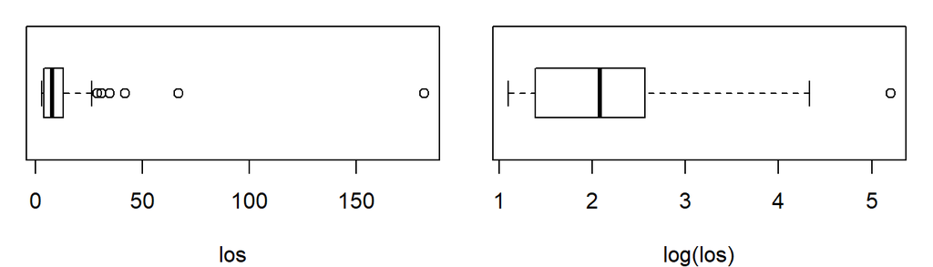

The outliers tend to inflate the variance of the weighted mean. Although the outliers are not some kind of error, it is beneficiary to use estimators other than the weighted mean to estimate the population average of los. We are interested in robust estimators which—although being biased as estimators of the population mean—will often have a smaller mean square error than the weighted mean; thus, are more efficient.

## 2 Trimming

### 2.1 Bare-bone methods

The following estimation methods are available.

| `weighted_mean_trimmed()` | `weighted_total_trimmed()` |
| --- | --- |

In place of the weighted mean, we consider the 5% one-sided trimmed weighted population mean of los. The lower end of the distribution is not trimmed (lower bound: `LB = 0`). The 5% largest observations are trimmed (upper bound: `UB = 0.95`).

```r
> weighted_mean_trimmed(los, weight, LB = 0, UB = 0.95)
[1] 9.323529
```

We obtain an estimate of (roughly) 9.3 days. Note that the return value is a scalar.

If a bare-bone method is called with argument `info = TRUE`, the function returns a list, the names of which are shown below.

```r
> m <- weighted_mean_trimmed(los, weight, LB = 0, UB = 0.95, info = TRUE)
> names(m)
[1] "characteristic" "estimator"      "estimate"       "variance"
[5] "residuals"      "model"          "design"         "call"
```

### 2.2 Survey methods

The survey methods are:

| `svymean_trimmed()` | `svytotal_trimmed()` |
| --- | --- |

As before, we are interested in computing the 5% one-sided trimmed weighted population mean of los. In contrast to `weighted_mean_trimmed()`, the method `svymean_trimmed()` computes the standard error of the estimate using the functionality of the `survey` package.

```r
> m <- svymean_trimmed(~los, dn, LB = 0, UB = 0.95)
> m
     mean    SE
los 9.324 1.064
```

The estimated location, variance, and standard error of the estimator can be extracted from object `m` with the following commands.

```r
> coef(m)
     los
9.323529
> vcov(m)
    Variance
los 1.131988
> SE(m)
[1] 1.063949
```

The `summary()` method summarizes the most important facts about the estimate. The summary is particularly useful for *M*-estimators (see below) but less so for other estimators.

```r
> summary(m)
Weighted trimmed estimator (0, 0.95) of the population mean

     mean    SE
los 9.324 1.064

Sampling design:
Independent Sampling design
svydesign(ids = ~1, fpc = ~fpc, weights = ~weight, data = losdata)
```

Additional utility functions are `residuals()`, `fitted()`, and `robweights()`. These functions are mainly relevant for *M*-estimators.